# Homelessness in U.S. How many…

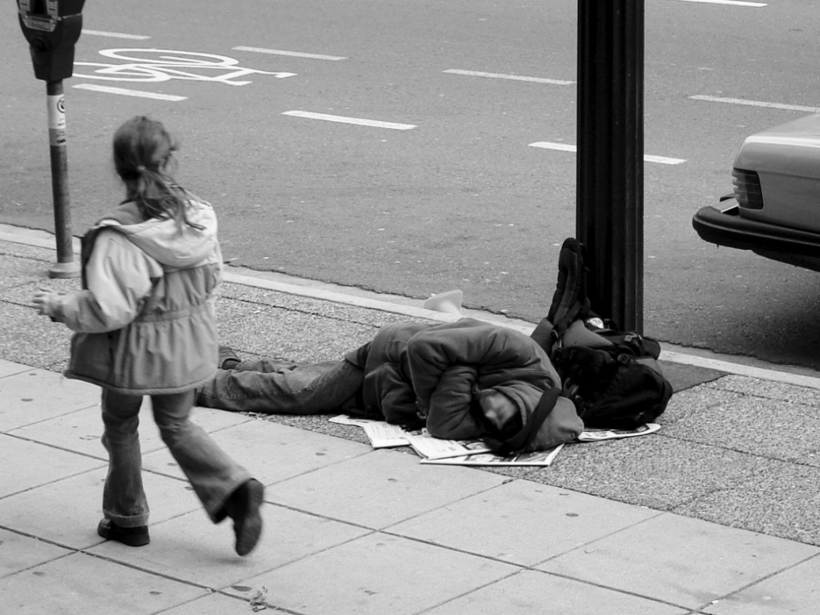

### are they?

A lot of people are homeless in the U.S. In fact, in 2015 they were 558,573 and the 21% (115,738) of them were lived in **California**. By counts California is followed by **New York**, **Florida** and **Texas** doing almost the 50% of all homeless people in U.S.

The next chart is a representation of the distribution of the homeless people. Each icon represent ~5586 peolpe.

[interactive chart not shown]

### were they?

However the previous chart don’t consider the population size of each state hidding **crucial information**.

In fact, the previous years the **Distric of Columnbia** has been the state with the greatest rate of homelessness people by far followed by **Hawaii** and **New York**.

[interactive chart not shown]

### they will be?

There is **hope**.

Every year, the number is reduced approximately by 2.85% and these numbers try to convince us there will be less poeople without home… But is not about numbers, is **about us** to change this reality making better choices, making a better world to live.

[interactive chart not shown]